# Previsão do tempo de chegada dos ônibus

2024-07-02

## Introducão

### Objetivo

- Usar os dados históricos da SMTR para prever tempos de chegada dos ônibus

### Prévia dos resultados

- Identificamos o tempo de chegada de 75% das observações
- Treinamos modelos estatísticos para prever esses tempos
- No modelo com melhor desempenho, obtivemos:
  - Erro médio de menos de 2 minutos
  - Em termos percentuais, erro abaixo de 20%

## Construção da base de dados

## Fontes de dados

### GTFS

- Itinerários possíveis de cada serviço
- Paradas de cada itinerário

### GPS dos ônibus

- Informações de cada ônibus, a cada 30segs-1min
- Coordenadas dos ônibus, velocidade, serviço

## Desafio

- Montar uma base de dados em que possamos prever os tempos de chegada
- Calcular quanto tempo cada ônibus levou para chegar a cada ponto.

### Passos:

1. Identificar qual itinerário cada ônibus está seguindo
2. Detectar todos os pontos que o ônibus tem pela frente
3. Calcular em quantos minutos ele chegou em cada um dos pontos

## Identificando itinerários

Exemplo: linha 309

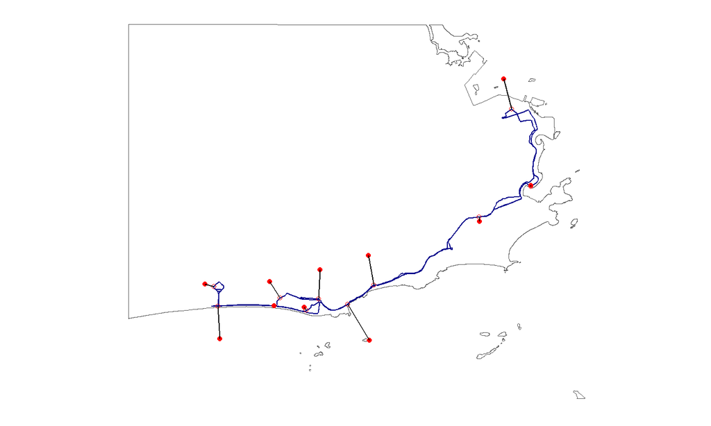

- Projetamos cada observação em seus itinerários possíveis (em geral, ida/volta)

## Identificando itinerários

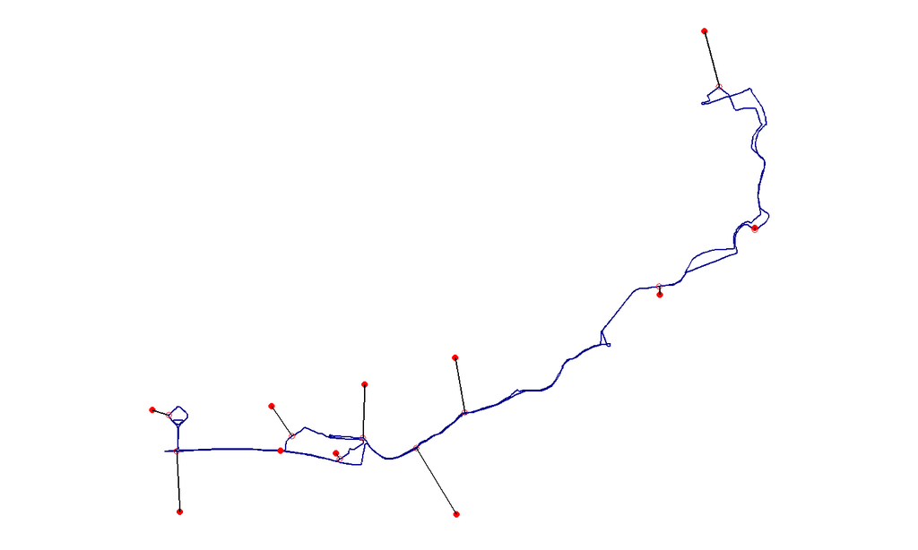

- Tendo os pontos projetados, calculamos a distância que o ônibus viajou ao longo de cada itinerário
- Se essa distância aumenta por 5 observações seguidas, o itinerário deve estar correto
- Se ainda resta mais de um itinerário possível, descartamos

## Identificando itinerários

- Com os itinerários identificados, a base tem o formato

| ID Veículo | Horário | … | Shape ID | Distância viajada |
| --- | --- | --- | --- | --- |
| A1 | 13:00 | … | S1 | 600m |
| A1 | 13:01 | … | S1 | 900m |
| A2 | 13:00 | … | S2 | 200m |

- Cerca de 4 milhões de observações por dia, em média

## Identificando paradas

- Dados do GTFS têm a localização de todas as paradas de um itinerário
- Pegamos as 20 paradas seguintes do ônibus, com base na distância projetada
- Um exemplo: cada observação da base de dados, como

| ID Veículo | Horário | … |
| --- | --- | --- |
| A1 | 13:00 | … |

## Identificando paradas

- Se transforma em uma observação por ponto

| ID Veículo | Horário | … | Parada | Distância até a parada |
| --- | --- | --- | --- | --- |
| A1 | 13:00 | … | A | 200m |
| A1 | 13:00 | … | B | 600m |
| A1 | 13:00 | … | C | 1100m |

- A base de GPS tem cerca de 5 milhões de observações/dia, em média
- Se cada ônibus tem 20 pontos pela frente, 100 milhões de observações
- Em um mês, são 3 bilhões de observações – que de fato obtemos

## Medindo tempos de chegada

- Queremos adicionar uma nova coluna a base, medindo em quantos minutos cada ônibus chegou a cada ponto
- Registramos o horário em que o ônibus chega ao ponto

## Caça aos outliers

- Algumas observações tinham tempos de chegada de muitas horas
- Criamos alguns filtros para:
  - Ônibus que desaparecem por alguns minutos
  - Ônibus que não mudam de posição
  - Ônibus distantes do itinerário
- Nessas observações (túneis, garagem, linha incorreta), não conseguimos identificar os tempos de chegada

## Base de validação

| Nome | Detalhes |
| --- | --- |
| Data | data |
| Serviço | código da linha |
| Posição do ônibus | longitude e latitude |
| Velocidade instantânea | km/h |
| Velocidade média | km/h, média dos últimos 10mins |
| Número do ponto | de 1, …, N |
| Distância ao ponto | m |
| Distância viajada | m |
| Quantos pontos à frente | de 1 a 20 |
| Tempo de chegada ao ponto | quantos mins até chegar |
| ID do Itinerário | código shape_id |
| Hora | 12h, 13h, … |
| Dia da semana | de 1 a 7 |

## Observações preservadas

| Número | Dados de GPS | Dados identificados |
| --- | --- | --- |
| Serviços | 492 | 430 |
| Observações | 142.979.033 | 105.955.906 |

- Perda de cerca de 25%
- Natural que nem todas sejam identificáveis, mas deve haver problemas com alguns serviços

## Modelos de previsão

## Modelos

- Modelos de regressão

\[ \text{Tempo de chegada} = F\Big(\text{dist}, \text{veloc}, \text{hora}, \text{trajeto}, \dots \Big) \]

- Modelo mais básico/benchmark: Médias históricas
  - Quantos minutos, em média, este serviço leva do ponto A ao ponto B às 17h de uma quinta-feira?
- Modelos mais complexos: Random Forest e Redes Neurais
  - Aproveitam todas as variáveis, espremendo o máximo dos dados
  - Aprendem relações não-lineares entre as variáveis

## Random Forest

- Estima muitas árvores de regressão com subamostras; tira a média
- Captura relações não-lineares e padrões complexos

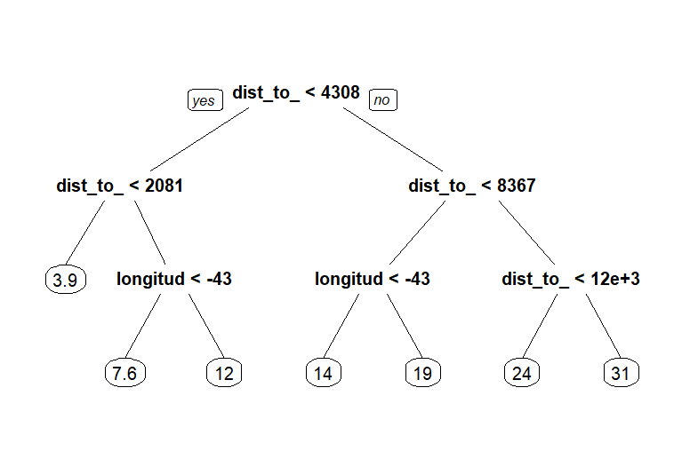

Árvore de regressão para o 309

## Índice de importância das variáveis

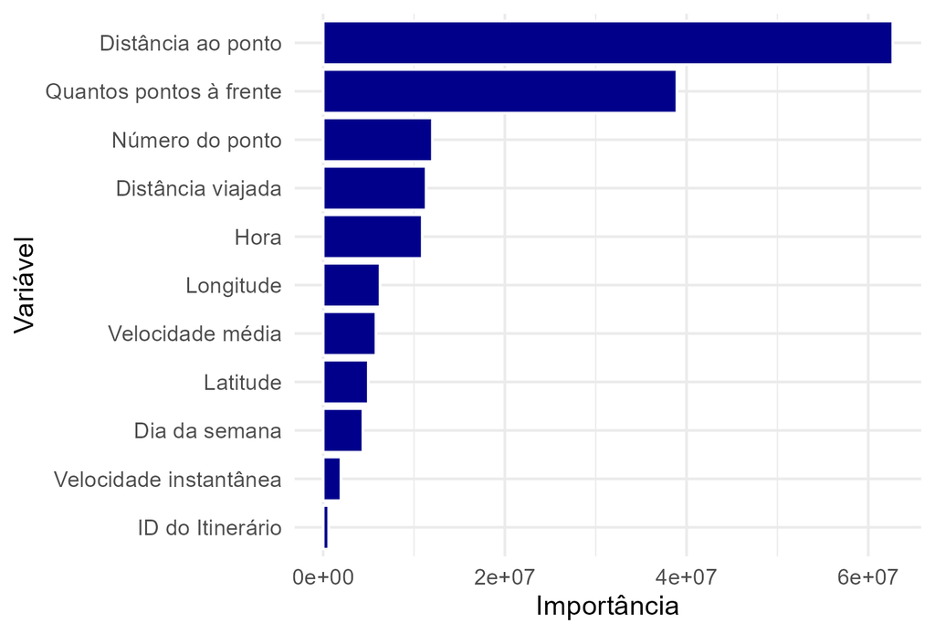

Linha 309

## Random Forest: erros de previsão

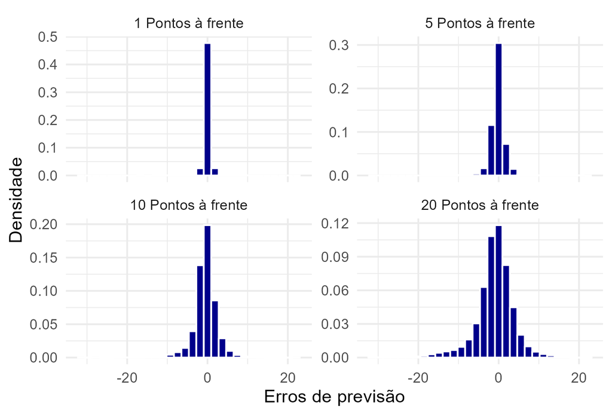

Linha 309

## Redes Neurais

- Combinações lineares entre as variáveis, com funções de ativação não lineares

[figure not shown]

## Treino e teste

- Escolhemos maio deste ano para testar os modelos
  - Base de treino: 1 a 21 de maio
  - Base de teste: 22 a 31 de maio
- Os modelos apenas aprendem com as observações da base de treino
- Base de teste é usada para medir quão bem eles prevêem fora da amostra
- Para ser viável rodar, armazenamos os dados de cada serviço em um arquivo separado
  - Treinamos um modelo de cada tipo por linha

## Resultados

## Resumo das previsões

| Modelo | RMSE | MAE | MAPE | MAD |
| --- | --- | --- | --- | --- |
| Médias históricas | 4,26 | 2,71 | 0,33 | 1,58 |
| Random Forest | 2,51 | 1,55 | 0,17 | 0,87 |
| Neural Network | 4,86 | 3,44 | 0,57 | 2,38 |

- Random Forest teve melhor desempenho

## Qualidade da previsão em função da distância

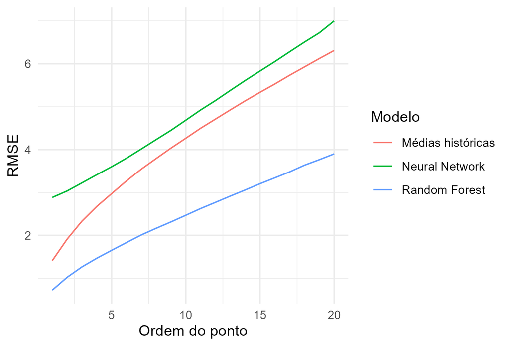

Raiz do erro quadrático médio

## Qualidade da previsão em função da distância

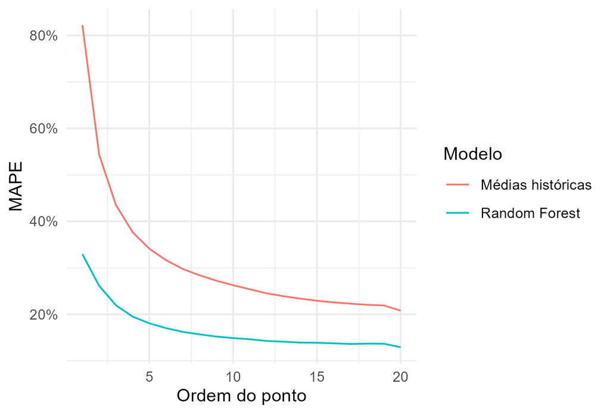

Erro percentual absoluto médio

## Possíveis próximos passos

## Cobertura das linhas

- Investigar quais serviços têm maior perda de observações e por que
- Identificamos algumas anomalias nos itinerários do GTFS que levam a perdas
  - Algumas shapes vêm em multilinestrings, e nem sempre é claro se as linestrings estão em ordem ou se se sobrepõem
- Maior dificuldade é em identificar o ID do itinerário nos dados – talvez seja possível direto pelo GPS
- Pode ser melhor juntas agrupar serviços, ex: 309, SN309 no mesmo, para ter maior volume de dados

## Aprimoramento dos modelos

- Analisar que tipo de observações têm erros de previsão maiores – de um determinado serviço, em determinado trajeto?
- Diferentes arquiteturas de Redes Neurais podem prever melhor
  - Incluir mais camadas pode ajudar, mas tem maior custo computacional
  - Tentar diferentes funções de ativações, taxas de aprendizagem
  - Transformar variáveis em uma série de indicadoras